# Ciência de Dados para Todos (Data Science For All) - 2018.1 - Análise da Produção Científica e Acadêmica da Universidade de Brasília - Relatório Final da Disciplina - Departamento de Ciência da Computação da UnB

Raphael Soares, Paulo Henrique Ferreira e Nur Corezzi

06/07/2018

# Introdução

O presente relatório tem por objetivo descrever e analisar 3 programas de pós-graduação da UNB, tendo como foco principal dois programas de Pós-Graduação em Matemática da UnB e o programa de Ensino em Ciências. Serão analisados o contexto dos programas de pós-graduação (PPG), para que sejam expostas de maneira organizada as informações levantadas pelos datasets disponibilizados pela plataforma do E-Lattes. Também serão propostas relações com outras bases de dados da UNB como a base do DGP(dados de grupos de pesquisa) e da base OASIS que contém informações sobre as produções nacionais. A metodologia de análise a ser seguida é uma aproximação ao CRISP-DM que visa unificar as formas de se realizar mineração de dados, para que os procedimentos possam ser reproduzidos e possuem algum nivel de confiabilizade com relação ao resultados obtidos.

# Metodologia

## Delimitações iniciais

Em aderência à estrutura do CRISP-DM, algumas delimitações de contexto para o trabalho são apresentadas a seguir:

### Domínio de Aplicação do projeto

O domínio de aplicação do projeto é o da produção científica e acadêmica brasileira, mais específicamente a produção científica ou produção acadêmica de um subgrupo de pesquisadores vinculados à Universidade de Brasília.

### Tipo de Problema abordado

O tipo de problema abordado é o da produção de análises descritivas, quantitativas e de modelagem computacional ou estatística, que permitam caracterizar como e porque ocorre a produção científica e acadêmica de um grupo de pesquisadores. Essa caracterização visa subsidiar a tomada de decisão por membros do Sistema Nacional de Pós-Graduação. É importante que estas analises sejam feitas poís servem de aprimoramento as instituições públicas, para que possam produzir pesquisas e profissionais de qualidade.

Grande parte destas informações não estão disponibilizadas de maneira prática de serem interpretadas, portanto é necessário que sejam tratadas para permitirem melhor acesso e interpretação a usuários que tenham interesse nas produções nacionais acadêmicas. Além disso boa parte dos datasets sendo estudados não foram devidamente padronizados e muitas vezes possuem dados incorretos que também devem ser corrigidos e serão tratados neste relatório.

## Modelo de Referência CRISP-DM

### Por que usar o CRISP-DM?

Imagine uma analogia entre um projeto de datamining e a preparação de uma receita de bolo para ser usada em uma fábrica. Para iniciar a produção, com base numa receita de comprovada eficácia (metodológica e científica), você tem que minerar os ingredientes (dados) em um grande supermercado (*dataset*). Com os ingredientes você precisa aplicar um método (a forma de misturá-los), colocar os ingredientes numa determinada ordem, mexer por um certo tempo, aquecer por tantos minutos até o bolo ficar pronto e ser aprovado em um ou mais testes de degustação.

Tendo por objetivo fazer com que essa receita (script de mineração de dados) possa ser executada com sucesso diversas vezes, numa fábrica, será que outro cozinheiro (cientista) que reproduzisse a receita (método) chegaria ao mesmo resultado? Se a metodologia (receita) já foi bastante testada, então é bem provável que o resultado será o mesmo e seu produto (receita de bolo) será aceito para a produção (*deployment*) de análises para consumo futuro, com base em fundamentos científicos.

### Organização hierárquica de atividades em fases

Dentro de cada fase no CRISP-DM existe uma estrutura hierárquica de atividades genéricas para serem realizadas. Cada uma dessas atividades **genéricas** pode determinar a execução de atividades **específicas**.

Voltando ao exemplo do bolo, a atividade ” 1. Entendimento do Bolo” poderia conter uma atividade genérica chamada “1.1. Determinar para que o bolo servirá (simples café da manhã? bolo de aniversário? bolo de casamento?)“. Dentro dessa atividade genérica poderia haver atividades específicas como “1.1.1.Entrevistar o contratante para obter detalhes de onde o bolo será usado?“; “1.1.2. Conversar com os convidados sob alguma necessidade especial (sem lactose? sem glútem?)“, etc.

### Seis Fases do CRISP-DM

Com base no apresentado, segue uma descrição um pouco mais detalhada das seis fases de um projeto no CRISP-DM. Neste relatório será seguido um modelo aproximado uma vez que não será realizada a fase de modelagem. A seguir seguem as etapas simplificadas do CRISP-DM.

#### Entendimento do Negócio

É o desenvolvimento dos objetivos e declaração das necessidades do projeto sob a perspectiva do negócio, para transformar isso tudo em definição de um problema de data mining. No caso desse relatório irá se buscar encontrar dados referentes aos perfis, publicações e orientações dos discentes dos programas de pós-graduação da Matematica, Matematica Rede e Ensino em Ciências. Deve-se também definir um grupo de objetivos, um plano para a realização do projeto e um critério de sucesso. Como objetivo para a parte de datamining desse relatório tem-se conseguir dados referentes às seguintes áreas:

- Áreas com resultados mais relevantes / expressivos;
- Nível de Internacionalização;
- Principais congressos e eventos da área no Brasil e no mundo;
- Principais revistas e local de publicação de trabalhos no Brasil e no mundo;
- Quantitativo de pessoas e programas dentro do universo;
- Grupos de pesquisa associados ou que os professores / pesquisadores fazem parte.

Quanto ao plano para realização do projeto, será realizada as seguintes etapas: * Tratamento dos dados para transformá-lo em um dataset; * Análise dos dados para a criação de resultados relevantes; * Análise dos resultados para encontrar os dados citados nos objetivos.

#### Entendimento dos Dados

O segundo estágio do CRISP-DM requer que se tenha acesso ao dado listado nos recursos do projeto. Essa fase requer a realização da descrição, exploração, verificação da qualidade e relatório da qualidade dos dados.

Os dados analisados nesse relatório foram pegos a partir do arquivo Matematica.profile.json que representa o dataset do programa de pós graduação em Matemática (código: 53001010003P2) e conta com uma lista de docentes e seus dados pessoais. Essa descrição e exploração foi feita utilizando do comando View no rstudio. A qualidade dos dados se encontra bastante satisfatória, com alguns problemas na padronização de alguns dados como o endereço que em alguns casos apresenta diferentes nomes para um mesmo curso como “Matematica” e “Matemática”.

#### Preparação dos Dados

Aqui os dados são “filtrados” retirando-se partes que não interessam e selecionando-se os “campos” necessários para o trabalho de mineração. São 5 as atividades genéricas nesta fase de preparação dos dados:

- Seleção dos dados. Envolve identificar quais dados, da nossa “montanha de dados”, serão realmente utilizados. Quais variáveis dos dados brutos serão convertidas para o dataset? Não é raro cometer o erro de selecionar dados para um modelo preditivo com base em uma falsa ideia de que aqueles dados contém a resposta para o modelo que se quer construir. Surge o cuidado de se separar o sinal do ruído (Silver, Nate. The Signal and the Noise: Why so many predictions fail — but some don’t. USA: The Penguin Press HC, 2012.).
- Limpeza dos dados.
- Construção dos dados. Envolve a criação de novas variáveis a partir de outras presentes nos `datasets.`
- Integração dos dados. Envolve a união (merge) de diferentes tabelas para criar um único `dataset` para ser utilizado no R, por exemplo.
- Formatação dos dados. Envolve a realização de pequenas alterações na estrutura dos dados, como a ordem das variáveis, para permitir a execução de determinado método de data mining.

#### Modelagem

No CRISP-DM este estágio envolve a construção e avaliação do modelo, podendo ser realizada em quatro atividades genéricas: * Seleção das técnicas de modelagem; * Realização de testes de modelagem, onde diferentes modelos são previamente testados e avaliados. Pode-se dividir o dataset criado na etapa anterior para se ter uma base de treino na construção de modelos, e outra pequena parte para validar e avaliar a eficiência de cada modelo criado até se chegar ao mais “eficiente”. * Construção do modelo definitivo, com base na melhor experiência do passo anterior. * Avaliação do modelo.

#### Avaliação

Aqui os resultados não são apenas avaliados, mas se verifica se existem questões relacionadas à organização que não foram suficientemente abordadas. Deve-se refletir se o uso arepetido do modelo criado pode trazer algum “efeito colateral” para a organização.

Nesta fase, pode-se trabalhar com 3 atividades genéricas: * Avaliação dos resultados; * Revisão do processo, por meio da qual verifica-se se o modelo foi construído adequadamente. As variáveis (passadas) para construir o modelo estarão disponíveis no futuro? * Determinação dos etapas seguintes. Pode ser necessário decidir-se por finalizar o projeto, passar à etapa de desenvolvimento, ou rever algumas fases anteriores para a melhoria do projeto.

#### Implantação (`deployment`)

Foi realizado o planejamento de implantação dos produtos desenvolvidos (scripts, no caso do executado nesta disciplina) para o ambiente operacional, para seu uso repetitivo, envolvendo atividades de monitoramento e manutenção do sistema (script) desenvolvido. A fase de implantação concluir com a produção e apresentação do relatório final com os resultados do projeto.

São atividades genéricas na fase de **implantação**: * Planejamento da transição dos produtos; * Planejamento do monitoramento dos produtos em utilização no ambiente operacional; * Planejamento de manuteção a ser eventualmente efetuada no produto (scripts); * Produção do relatório final; * Apresentação do relatório final; * Revisão sobre a execução do projeto, com registro de lições aprendidas.

No contexto do projeto realizado no âmbito desta disciplina, a responsabilidade por execução de todas essas atividades é dos alunos, com exceção da apresentação do relatório final, que não será realizada.

# CRISP-DM Fase 1 - Entendimento do Negócio

## O que é o Sistema Nacional de Pós-Graduação?

A produção do conhecimento científico, no Brasil, é predominantemente efetuada por meio do Sistema Nacional de Pós-Graduação - SNPG, e mais fortemente relacionada com a formação de doutores nesse sistema (Pátaro e Mezzomo, 2013), por meio de cursos de pós-graduação *strictu sensu*.

Fernandes e Sampaio (2017) já indicaram que a ciência é reconhecidamente um elemento essencial para o desenvolvimento social e econômico de qualquer nação. Assim sendo, faz-se mister aprimorar o SNPG como forma de promoção desse crescimento, visando maximizar o retorno decorrente do emprego dos recursos nele aplicados. A promoção do crescimento do SNPG se dá predominantemente por meio de avaliações regulares de seus programas de pós-graduação, sob responsabilidade da CAPES, que realiza a cada quatro anos um complexo (Leite, 2018, p. 13) e custoso processo de coleta de dados, análise e deliberação sobre as pós-graduações *strictu sensu*, em coerência com o estabelecido no Plano Nacional de Pós-Graduação (PNPG) 2012-2020 (CAPES, 2010) e nos diversos documentos que definem os critérios de organização da pós-graduação em cada área do conhecimento (CAPES, 2018). Leite (2018) faz uma apresentação geral de como se organizam e são avaliadas as pós-graduações no Brasil.

O Plano Nacional de Pós-Graduação (PNPG), por outro lado, define diretrizes estratégicas para desenvolvimento da pós-graduação brasileira, que deve abordar prioritariamente grandes temas de interesse nacional, tais como a redução das assimetrias de desenvolvimento entre as regiões do Brasil, a formação de professores para a educação básica, a formação de recursos humanos para as empresas, a resposta aos grandes desafios brasileiros sobre Água, Energia, Transporte, Controle de Fronteiras, Agronegócio, Amazônia, Amazônia Azul (Mar), Saúde, Defesa, Programa Espacial, além de Justiça, Segurança Pública, Criminologia e Desequilíbrio Regional. O PNPG também traça as diretrizes para financiamento da pós-graduação e sua internacionalização, apresentando conclusões e recomendações.

As avaliações do SNPG, ao atribuirem mensurações de desempenho às diversas pós-graduações que dele fazem parte, geram incentivos e penalidades aos programas, tendo em vista a limitada disponibilidade de recursos para investimento em bolsas, taxas de bancada etc. Embora o sistema seja altamente sofisticado ele é também altamente criticado (Azevedo et al., 2016), sobretudo porque há percalços na busca por um equilíbrio entre as diferentes concepções de finalidade da ciência. Se de um lado a promoção do conhecimento gerado predominantemente nas ditas ciências *hard* constribui para criar fluxos econômicos mais intensos, isso não significa que essa promoção possa ocorrer em detrimento da menor promoção na geração de conhecimento sobre problemas sociais, predominantemente gerado nas ditas ciências *soft*, especialmente das áreas de humanidades, sob pena de ampliação de desigualdades (Azevedo et al., 2016).

Não há solução simples, mas postula-se, nesta disciplina, que uma maior agilidade na avaliação e a utilização de critérios mais objetivos, poderá facilitar a melhoria do sistema.

### Os Colégios, Grandes Áreas e Áreas da Pós-Graduação Brasileira

A partir de 2018, as diversas áreas da pós-graduação brasileira foram organizadas na forma de colégios, grandes áreas e áreas, conforme apresentam as tabelas a seguir.

#### Colégio de Ciências da vida

| CIÊNCIAS AGRÁRIAS | CIÊNCIAS BIOLÓGICAS | CIÊNCIAS DA SAÚDE |
| --- | --- | --- |
| Ciência de Alimentos | Biodiversidade | Educação Física |
| Ciências Agrárias I | Ciências Biológicas I | Enfermagem |
| Medicina Veterinária | Ciências Biológicas II | Farmácia |
| Zootecnia / Recursos Pesqueiros | Ciências Biológicas III | Medicina I |
| - | - | Medicina II |
| - | - | Medicina III |
| - | - | Nutrição |
| - | - | Odontologia |
| - | - | Saúde Coletiva |

#### Colégio de Ciências Exatas, Tecnológicas e Multidisciplinar

| CIÊNCIAS EXATAS E DA TERRA | ENGENHARIAS | MULTIDISCIPLINAR |
| --- | --- | --- |
| Astronomia / Física | Engenharias I | Biotecnologia |
| Ciência da Computação | Engenharias II | Ciências Ambientais |
| Geociências | Engenharias III | Ensino |
| Matemática / Probabilidade e Estatística | Engenharias IV | Interdisciplinar |
| Química | - | Materiais |

#### Colégio de Humanidades

| CIÊNCIAS HUMANAS | CIÊNCIAS SOCIAIS APLICADAS | LINGUÍSTICA, LETRAS E ARTES |
| --- | --- | --- |
| Antropol/Arqueol | Admin.Púb./Empr.,C.Contáb. e Tur. | Artes |
| Ciência Pol. e Rel. Int. | Arquit., Urban. e Design | Linguística e Literatura |
| Ciências da Religião e Teol. | Comunicação e Informação | - |
| Educação | Direito | - |
| Filosofia | Economia | - |
| Geografia | Planej. Urbano e Reg. / Demografia | - |
| História | Serviço Social | - |
| Psicologia | - | - |
| Sociologia | - | - |

Cada um desses colégios, grandes áreas e áreas de conhecimento possuem dinâmicas próprias, e, portanto, não há um modelo universal que se aplique a todas. Existem aspectos comuns, mas também grandes peculiaridades, descritas parcialmente nos correspondentes documentos de área disponíveis em CAPES (2018).

## A UnB dentro do Sistema Nacional de Pós-Graduação

### O que é a UnB?

A Universidade de Brasília é uma instituição de ensino superior composta por cinco campus em Brasília e cidades satélites que oferecem formação da graduação à pós-graduação. Do ponto de vista de sua produção científica a UnB ocupa atualmente a posição número 737 no ranking mundial de melhores universidades do mundo de acordo com o Center for World University Rankings (CWUR), que leva em consideração principalmente premiações, artigos, número de citações, pesquisas e publicações.

Em relação às demais universidades do Brasil, segundo o Ranking de Universidades Folha (2017) que classifica as melhores universidades do país, entre as 296 instituições públicas de nível superior a UnB se encontra na posição número 20 sendo a 11ª em número de teses publicadas, a 10ª e número de publicações em revistas nacionais e a 20ª em núméro de publicações por docente.

### Descrição das pós-graduações da UnB

Neste trabalho o foco será encima de três programas de pós-graduação da UNB. Entre eles dois programas do departamento de matemática e outro do programa de ensino em ciências. Nós próximos tópicos serão detalhados os contextos de cada PPG sendo trabalhado.

#### Programa de Pós-graduação de ensino em ciências

O programa de pós-graduação em ensino de ciências, tem como objetivo qualificar os professores de nível básico em matérias relativas a ciências e afins. O foco é dado no desenvolvimento de conteúdos de ciências, o que envolve aspectos teóricos, metodológicos e epistemológicos relativo ao ensino de ciências além do desenvolvimento e aprendizado de novas tecnologias que permitam a evolução do ensino.

O programa engloba professores com as mais diversas áreas de atuação e de diferentes cantos da universidade. Podemos citar como áreas a física, bioquímica, ecologia, história, química, genética, medicina, psicologia entre outras, com destaques para a participação do Instituto de Física, Química e Ciências Biológicas. Os programas englobam três linhas de pesquisa sendo elas: Ensino-Aprendizagem em Ciências da Natureza em seus mutilplos aspectos; Formação de Professores de Ciências da Natureza e Educação Científica e Cidadania.

A implementação do Programa de Pós-Graduação em Ensino de Ciências na UnB, se deu inicialmente em 2007 e desde 2010, tem sido ampliado seu quadro de docentes por meio do credenciamento de novos orientadores, principalmente a partir da aproximação com o curso de Licenciatura em Ciências Naturais da Faculdade UnB Planaltina.

O programa é composto por 19 professores que já realizaram cerca de 709 orientações ao longo dos anos de 2010 a 2017 com cerca de 174 dissertações de mestrado concluidas até o momento. Podemos observar abaixo as distribuições de cada orientação realizada ao longo dos anos. É possível observar um grande aumento na quantidade(relativa) de orientações realizadas de mestrado, o que pode ser explicado pelo aumento do número de novos orientadores credenciados ao PPG.

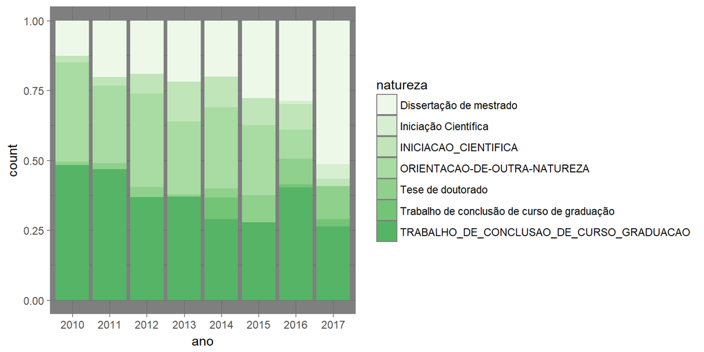

Abaixo teremos as quantidades absolutas totais de orientações realizadas ao longo dos anos de 2010 a 2017 apenas para complementar a distribuição acima apresentada:

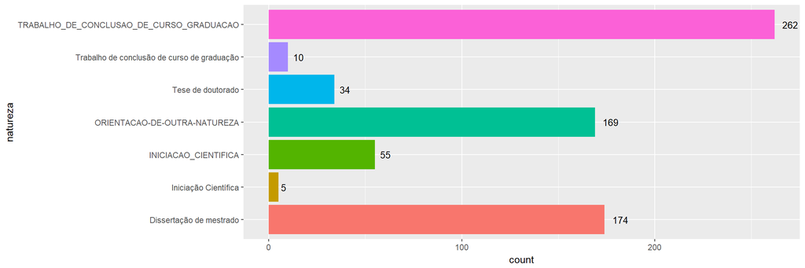

Em média os orientadores possuem nível de senioridade 7, tendo 5 como mínimo e 9 como máximo, o que indica que no geral os professores possuem bastante experiência no meio acadêmico, e pode ser relevante para explicar a quantidade de orientações realizadas pelo programa e também o número de publicações realizadas. No total os orientadores participam de 29 grupos de pesquisa e são em sua totalidade nascidos no brasil com uma idade média de 58 anos de idade. Entre os grupos aos quais os orientadores participam podemos citar os de Educação Científica e Cidadania, Ensino de Ciências e Mediação Pedagógica, Aprendizagem e mediação pedagógica, Ecologia e Comportamento e o grupo de Ensino de Química.

Atualmente estão sendo realizadas 74 orientações que incluem, mestrandos, doutorandos e PHDs. Deste conjunto existem alunos que vieram de diversas instituições, dentre elas Universidade Federal de Mato Grosso, Universidade Federal de Pernambuco, Universidade Federal de Sergipe e Centro Universitário Norte do Espírito Santo, porém nenhum estudante proveniente de instituições internacionais.

#### Programas de Pós-graduação da Matemática

Aqui será feita uma contextualização das áreas de pesquisa relacionadas ao programa de Pós-Graduação em Matemática da UnB, dos anos 2010 à 2017. Para tal está sendo apresentado dados de produção científica dos docentes do programa, retirados do currículo Lattes dos professores e do repositório `OASIS` do `IBICT` (Instituto Brasileiro de Informação em Ciência e Tecnologia).

O coordenador do PPG é o Carlos Alberto Pereira dos Santos e as subáreas de concentração são: **Álgebra, Análise, Geometria e Matemática Aplicada**. Mais informações do programa podem ser acessadas pelo site [sucupira](https://sucupira.capes.gov.br/sucupira/public/consultas/coleta/programa/viewPrograma.jsf?popup=true&cd_programa=53001010003P2).

O programa de Pós-Graduação em Matemática da UnB, iniciado em 1962, oferece Mestrado e Doutorado em Matemática nas subáreas de Álgebra, Análise, Geometria e Matemática Aplicada (Probabilidade, Física-Matemática e Computação). O corpo docente mantém um programa ativo de pesquisa, participa regular e ativamente de forma destacada em reuniões científicas e em corpos editoriais de revistas científicas, além de manter intercâmbio científico com diversas instituições do país e do exterior.

Há também um programa de mestrado profissional `PROFMAT`, que é um programa de pós-graduação stricto sensu em Matemática, reconhecido pelo Ministério da Educação e conduzindo ao título de Mestre. Tem como objetivo proporcionar formação matemática aprofundada relevante ao exercício da docência no Ensino Básico, visando dar ao egresso a qualificação certificada para o exercício da profissão de professor de Matemática.

O `PROFMAT` é um curso semipresencial ministrado por Instituições de Ensino Superior associadas em uma Rede Nacional, no âmbito do **Sistema Universidade Aberta do Brasil** (UAB). É coordenado pela Comissão Acadêmica Nacional, que opera sob a égide da Diretoria da **Sociedade Brasileira de Matemática** (SBM).

As Instituições de Ensino Superior que integram a Rede Nacional do `PROFMAT` são denominadas Instituições Associadas e são responsáveis, por intermédio das respectivas Coordenações Acadêmicas Institucionais, por toda a gestão local do `PROFMAT`, descritas no Regimento. Informações completas sobre este mestrado podem ser encontradas na página do [`PROFMAT`](http://www.profmat-sbm.org.br). Na Universidade de Brasília este curso é ofertado no âmbito do Instituto de Ciências Exatas, Departamento de Matemática.

O Departamento de Matemática da UnB obteve nota 7 na última avaliação trienal da Capes. Essa avaliação de excelência é o resultado de um longo, árduo e contínuo trabalho iniciado em 1962 por professores/colaboradores corajosos e idealistas que acreditaram em tornar o sonho do Departamento de Matemática da Universidade de Brasília uma realidade. Desde então, esse ideal vem sendo fortalecido com a chegada de novos professores/colaboradores que conduziram este programa ao reconhecimento da sua excelência.

# CRISP-DM Fase 2 - Entendimento dos Dados

## CRISP-DM Fase.Atividade 2.1 - Coleta inicial dos dados

Todos os arquivos com dados iniciais a seguir apresentados foram fornecidos pelos professores responsáveis pela disciplina. Os dados foram gerados no mês de maio de 2018, e compilam informações entre os anos de 2010 e 2017. Os arquivos estão no formato JSON, e seus atributos iniciais e conteúdos são apresentados a seguir.

A metodologia utilizada tenta seguir o que é proposto pelo modelo CRISP-DM. Inicialmente o contexto do programa de pós-graduação foi explorado, buscando o máximo possível de informações sobre o PPG incluindo seu funcionamento e suas áreas de pesquisa. Os dados foram buscados e explorados a partir do website do programa com o intuito de compreender melhor o contexto que será trabalhado.. Os dados utilizados para pesquisa foram tirados do dataset de publicações, orientações e perfis da Matemática do portal do programa e do [elattes](http://unb.elattes.com.br/user/login).

Uma vez compreendido do que se trata o programa os dados dispostos pelo E-Lattes foram explorados para um reconhecimento inicial. Pode-se notar que os dados vieram em formato JSON, englobando os universos de publicações, orientações, perfis e áreas de pesquisa dos orientadores do departamento, além dos dados referentes as bases do DGP e OASIS. Após importação devida os dados passaram por uma exploração inicial para entender sua formatação e se alguma modificação seria necessária para trabalhar com as ferramentas disponíveis framework da linguagem R.

Em seguida foi identificado que alguns dados não estavam totalmente preparados para a realização de buscas, uma vez que é necessária a formatação em tabelas (e não em listas) para a realização de filtragens e joins de maneira clara prática. Portanto os arquivos de publicações e perfis foram modificados para que fossem removidas algumas listas internas a estruturam que dificultavam sua utilização. Por exemplo, no arquivo de publicações, temos uma grande lista com 7 outras listas como elementos: periódico, livro, capítulo de livro, texto em jornais, evento, artigo aceito e demais tipos de produação bibliográfica.

Tendo os dados filtrados e organizados foram efetuadas consultas básicas com o intuito de ter uma visualização mais clara dos conjuntos de dados. As bibliotecas utilizadas para filtragem e visualização foram a `dplyr`, que permitem consultas semelhantes a consultas de bancos de dados, com dados organizadas em tabelas (em R conhecidas como dataframes), e a biblioteca `ggplot2` que possibilita a fácil criação de gráficos a parir de dataframes.

Após a realização das consultas foram geradas algumas conclusões que foram cruzadas com os dados iniciais obtidos a partir da avaliação do contexto do programa, apesar de o trabalho ter caráter expositivo foi gerado um modelo para tentar explicar algumas situações identificadas ao longo da pesquisa do PPG. O procedimento aqui demonstrado foi repetido até que fossem obtidos resultados satisfatórios assim como descreve o modelo CRISP-DM.

### Perfil profissional dos docentes vinculados às pós-graduações

```r
json.perfil <- "Matematica.profile.json"
file.info(json.perfil)
```

|  | size | isdir | mode | mtime | ctime | atime | exe |
| --- | --- | --- | --- | --- | --- | --- | --- |
| Matematica.profile.json | 654736 | FALSE | 666 | 2018-07-07 17:52:28 | 2018-07-07 17:52:28 | 2018-07-07 17:52:28 | no |

O arquivo Matematica.profile.json apresenta dados sobre o perfil de todos os docentes vinculados a programas de pós-graduação da UnB, entre 2010 e 2017. Esse arquivo foi fornecido pelos docentes responsáveis pela disciplina.

### Orientações de mestrado e doutorado realizadas pelos docentes vinculados às pós-graduações

```r
json.advise <- "Matematica.advise.json"
file.info(json.advise)
```

|  | size | isdir | mode | mtime | ctime | atime | exe |
| --- | --- | --- | --- | --- | --- | --- | --- |
| Matematica.advise.json | 235679 | FALSE | 666 | 2018-07-07 17:52:28 | 2018-07-07 17:52:28 | 2018-07-07 17:52:28 | no |

O arquivo Matematica.advise.json apresenta dados sobre o orientações de mestrado e doutorado feitas por todos os docentes vinculados a programas de pós-graduação da UnB, entre 2010 e 2017. Esse arquivo foi fornecido pelos docentes responsáveis pela disciplina.

### Produção bibliográfica gerada pelos docentes vinculados às pós-graduações

```r
json.producao.bibliografica <- "Matematica.publication.json"
file.info(json.producao.bibliografica)
```

|  | size | isdir | mode | mtime | ctime | atime | exe |
| --- | --- | --- | --- | --- | --- | --- | --- |
| Matematica.publication.json | 313273 | FALSE | 666 | 2018-07-07 17:52:28 | 2018-07-07 17:52:28 | 2018-07-07 17:52:28 | no |

O arquivo Matematica.publication.json apresenta dados sobre a produção bibliográfica gerada por todos os docentes vinculados a programas de pós-graduação da UnB, entre 2010 e 2017.

### Agrupamento dos docentes conforme áreas de atuação

```r
json.researchers_by_area <- "Matematica.researchers_by_area.json"
file.info(json.researchers_by_area)
```

|  | size | isdir | mode | mtime | ctime | atime | exe |
| --- | --- | --- | --- | --- | --- | --- | --- |
| Matematica.researchers_by_area.json | 1161 | FALSE | 666 | 2018-07-07 17:52:28 | 2018-07-07 17:52:28 | 2018-07-07 17:52:28 | no |

O arquivo Matematica.researchers_by_area.json apresenta as vinculações de todos os docentes que declararam atuar em cada uma das áreas de pós-graduação do Sistema Nacional de Pós-Graduação da CAPES, conforme apresenta-se registrada essa informação no currículo Lattes de cada um, em data recente.

```r
file.info('Matematica.graph.json')
```

|  | size | isdir | mode | mtime | ctime | atime | exe |
| --- | --- | --- | --- | --- | --- | --- | --- |
| Matematica.graph.json | 6179 | FALSE | 666 | 2018-07-07 17:52:28 | 2018-07-07 17:52:28 | 2018-07-07 17:52:28 | no |

## CRISP-DM Fase.Atividade 2.2 - Descrição dos Dados

Para ler e manipular inicialmente esses dados, serão usadas primordialmente as bibliotecas seguintes

```r
library(jsonlite)
library(listviewer)
```

```r
library(readxl)
library(readr)
#library(readtext)
library(ggplot2)
suppressMessages(library("tidyverse"))
```

### Descrição dos dados do perfil

```r
unb.prof <- fromJSON("Matematica.profile.json")
```

A quantidade de docentes sob análise é apresentada a seguir.

```r
length(unb.prof)
```

```
## [1] 44
```

Para gerar uma apresentação inicial dos dados que estão contido nos dados de perfil dos docentes, pode-se usar a função glimpse, da biblioteca dplyr, como ilustra o código seguinte, que apresenta os atributos típicos que podem ser obtidos relativamente a um pesquisador específico, o mais antigo docente ainda em exercício na UnB a ter criado seu registro na plataforma Lattes.

```r
library(dplyr)
glimpse(unb.prof[[1]], width = 30)
```

```
## List of 7
##  $ nome                  : chr "Norai Romeu Rocco"
##  $ resumo_cv             : chr "Possui graduação em Matemática (licenciatura plena) pela Universidade Estadual Paulista Júlio de Mesquita Filho"| __truncated__
##  $ areas_de_atuacao      :'data.frame':  5 obs. of  4 variables:
##   ..$ grande_area  : chr [1:5] "CIENCIAS_EXATAS_E_DA_TERRA" "CIENCIAS_EXATAS_E_DA_TERRA" "CIENCIAS_EXATAS_E_DA_TERRA" "CIENCIAS_EXATAS_E_DA_TERRA" ...
##   ..$ area         : chr [1:5] "Matemática" "Matemática" "Matemática" "Ciência da Computação" ...
##   ..$ sub_area     : chr [1:5] "" "Álgebra" "Álgebra" "Matemática da Computação" ...
##   ..$ especialidade: chr [1:5] "" "" "Grupos de Álgebra Não-Comutaviva" "Matemática Simbólica" ...
##  $ endereco_profissional :List of 8
##   ..$ instituicao: chr "Universidade de Brasília"
##   ..$ orgao      : chr "Instituto de Ciências Exatas"
##   ..$ unidade    : chr "Departamento de Matemática"
##   ..$ DDD        : chr "061"
##   ..$ telefone   : chr "31076442"
##   ..$ bairro     : chr "Asa Norte"
##   ..$ cep        : chr "70910900"
##   ..$ cidade     : chr "Brasília"
##  $ producao_bibiografica :List of 4
##   ..$ ARTIGO_ACEITO                         :'data.frame':   1 obs. of  10 variables:
##   .. ..$ natureza        : chr "NAO_INFORMADO"
##   .. ..$ titulo          : chr "Finiteness conditions for the non-abelian tensor product of groups"
##   .. ..$ periodico       : chr "MONATSHEFTE FUR MATHEMATIK"
##   .. ..$ ano             : chr "2017"
##   .. ..$ volume          : chr ""
##   .. ..$ issn            : chr "00269255"
##   .. ..$ paginas         : chr " - "
##   .. ..$ doi             : chr "10.1007/s00605-017-1143-x"
##   .. ..$ autores         :List of 1
##   .. ..$ autores-endogeno:List of 1
##   ..$ DEMAIS_TIPOS_DE_PRODUCAO_BIBLIOGRAFICA:'data.frame':   7 obs. of  9 variables:
##   .. ..$ natureza          : chr [1:7] "DIVULGAÇÃO DE RESULTADOS DE PESQUISA" "DIVULGAÇÃO DE RESULTADOS DE PESQUISA" "DIVULGAÇÃO DE RESULTADOS DE PESQUISA" "DIVULGAÇÃO DE RESULTADOS DE PESQUISA" ...
##   .. ..$ titulo            : chr [1:7] "NON-ABELIAN TENSOR SQUARE OF FINITE-BY-NILPOTENT GROUPS" "The q-tensor square of finitely generated nilpotent groups, q >=0" "The q-tensor square of finitely generated nilpotent groups, q >=0" "THE NON-ABELIAN TENSOR SQUARE OF RESIDUALLY FINITE GROUPS" ...
##   .. ..$ ano               : chr [1:7] "2015" "2016" "2016" "2016" ...
##   .. ..$ pais_de_publicacao: chr [1:7] "Estados Unidos" "Estados Unidos" "Estados Unidos" "Estados Unidos" ...
##   .. ..$ editora           : chr [1:7] "" "ArXiv.com - Cornell University Library" "ArXiv.com - Cornell University Library" "ArXiv.com - Cornell University Library" ...
##   .. ..$ doi               : chr [1:7] "" "" "" "" ...
##   .. ..$ numero_de_paginas : chr [1:7] "8" "12" "12" "11" ...
##   .. ..$ autores           :List of 7
##   .. ..$ autores-endogeno  :List of 7
##   ..$ EVENTO                                :'data.frame':   1 obs. of  11 variables:
```

[output cut: 51 more lines]

```
##   ..$ ORIENTACAO_EM_ANDAMENTO_DOUTORADO:'data.frame':    1 obs. of  13 variables:
##   .. ..$ natureza                   : chr "Tese de doutorado"
##   .. ..$ titulo                     : chr "Quadrado Tensorial não Abeliano de certas classes de Grupos Finitos"
##   .. ..$ ano                        : chr "2014"
##   .. ..$ id_lattes_aluno            : chr "1933036212945705"
##   .. ..$ nome_aluno                 : chr "Juliana Silva Canella"
##   .. ..$ instituicao                : chr "Universidade de Brasília"
##   .. ..$ curso                      : chr "Matemática"
##   .. ..$ codigo_do_curso            : chr "51500035"
##   .. ..$ bolsa                      : chr "SIM"
##   .. ..$ agencia_financiadora       : chr "Coordenação de Aperfeiçoamento de Pessoal de Nível Superior"
##   .. ..$ codigo_agencia_financiadora: chr "045000000000"
##   .. ..$ nome_orientadores          :List of 1
##   .. ..$ id_lattes_orientadores     :List of 1
##  $ senioridade           : chr "8"
```

### Descrição dos dados de orientações

```r
unb.adv <- fromJSON("Matematica.advise.json")
names(unb.adv)
```

```
## [1] "ORIENTACAO_EM_ANDAMENTO_DE_POS_DOUTORADO"
## [2] "ORIENTACAO_EM_ANDAMENTO_DOUTORADO"
## [3] "ORIENTACAO_EM_ANDAMENTO_MESTRADO"
## [4] "ORIENTACAO_EM_ANDAMENTO_GRADUACAO"
## [5] "ORIENTACAO_EM_ANDAMENTO_INICIACAO_CIENTIFICA"
## [6] "ORIENTACAO_CONCLUIDA_POS_DOUTORADO"
## [7] "ORIENTACAO_CONCLUIDA_DOUTORADO"
## [8] "ORIENTACAO_CONCLUIDA_MESTRADO"
## [9] "OUTRAS_ORIENTACOES_CONCLUIDAS"
```

```r
names(unb.adv$ORIENTACAO_CONCLUIDA_DOUTORADO)
```

```
## [1] "2010" "2011" "2012" "2013" "2014" "2015" "2016" "2017"
```

```r
length(unb.adv$ORIENTACAO_CONCLUIDA_DOUTORADO$`2016`$natureza)
```

```
## [1] 16
```

```r
head(sort(table(unb.adv$ORIENTACAO_CONCLUIDA_DOUTORADO$`2017`$curso), decreasing = TRUE), 10)
```

```
##
##              Matemática Doutorado em Matematica Doutorado em Matemática
##                       8                       2                       1
##             Informática              Matematica
##                       1                       1
```

```r
head(sort(table(unb.adv$ORIENTACAO_CONCLUIDA_MESTRADO$`2017`$curso), decreasing = TRUE), 10)
```

```
##
##                           Matemática Mestrado em Matemática e Estatística
##                                   13                                    2
##                          Informática                           Matematica
##                                    1                                    1
```

### Descrição dos dados de produção bibliográfica

```r
unb.pub <- fromJSON("Matematica.publication.json")
names(unb.pub)
```

```
## [1] "PERIODICO"
## [2] "LIVRO"
## [3] "CAPITULO_DE_LIVRO"
## [4] "TEXTO_EM_JORNAIS"
## [5] "EVENTO"
## [6] "ARTIGO_ACEITO"
## [7] "DEMAIS_TIPOS_DE_PRODUCAO_BIBLIOGRAFICA"
```

```r
names(unb.pub$PERIODICO$`2012`)
```

```
##  [1] "natureza"         "titulo"           "periodico"
##  [4] "ano"              "volume"           "issn"
##  [7] "paginas"          "doi"              "autores"
## [10] "autores-endogeno"
```

```r
head(sort(table(unb.pub$PERIODICO$`2017`$periodico), decreasing = TRUE), 10)
```

```
##
##                   ANNALI DI MATEMATICA PURA ED APPLICATA
##                                                        4
##          Bulletin of the Australian Mathematical Society
##                                                        4
##                               Journal of Algebra (Print)
##                                                        4
##                                       JOURNAL OF ALGEBRA
##                                                        3
##             Electronic Journal of Differential Equations
##                                                        2
##                            ISRAEL JOURNAL OF MATHEMATICS
##                                                        2
##           Journal of Fixed Point Theory and Applications
##                                                        2
##                          JOURNAL OF GEOMETRY AND PHYSICS
##                                                        2
##                                  JOURNAL OF GROUP THEORY
##                                                        2
## JOURNAL OF THE LONDON MATHEMATICAL SOCIETY-SECOND SERIES
##                                                        2
```

```r
head(sort(table(unb.pub$LIVRO$`2015`$nome_da_editora), decreasing = TRUE), 10)
```

```
## Elsevier ENTCS - Electronic Notes in Theoretical Computer Science
##                                                                 1
```

### Descrição dos dados de agregação de docentes por área

```r
unb.area <- fromJSON("Matematica.researchers_by_area.json")
unb.area.df <- cbind(names(unb.area$`Areas dos pesquisadores`),
           (sapply(unb.area$`Areas dos pesquisadores`, function(x) length(x))))
rownames(unb.area.df) <- c(1:nrow(unb.area.df)); colnames(unb.area.df) <- c("Area", "Professores")
glimpse(unb.area.df)
```

```
##  chr [1:6, 1:2] "Ciência da Computação" "Engenharia Aeroespacial" ...
##  - attr(*, "dimnames")=List of 2
##   ..$ : chr [1:6] "1" "2" "3" "4" ...
##   ..$ : chr [1:2] "Area" "Professores"
```

```r
head(unb.area.df[])
```

```
##   Area                          Professores
## 1 "Ciência da Computação"       "4"
## 2 "Engenharia Aeroespacial"     "1"
## 3 "Engenharia Biomédica"        "1"
## 4 "Física"                      "1"
## 5 "Matemática"                  "40"
## 6 "Probabilidade e Estatística" "2"
```

## CRISP-DM Fase.Atividade 2.3 - Análise exploratória dos dados

Como já informado, a análise exploratória dos dados possibilita um entendimento mais profundo da relação estatística existente entre os dados dos *datasets* para um melhor entendimento da qualidade daqueles dados para os objetivos do projeto.

### Arquivo Profile

```r
# jsonedit(unb.prof)
# Número de áreas de atuação cumulativo
sum(sapply(unb.prof, function(x) nrow(x$areas_de_atuacao)))
```

```
## [1] 104
```

```r
# Número de áreas de atuação por pessoa
table(unlist(sapply(unb.prof, function(x) nrow(x$areas_de_atuacao))))
```

```
##
##  1  2  3  4  5  6
## 14 12 10  5  2  1
```

```r
# Número de pessoas por grande area
table(unlist(sapply(unb.prof, function(x) (x$areas_de_atuacao$grande_area))))
```

```
##
##                            CIENCIAS_EXATAS_E_DA_TERRA
##                          2                        100
##                ENGENHARIAS
##                          2
```

```r
# Número de pessoas que produziram os específicos tipos de produção
table(unlist(sapply(unb.prof, function(x) names(x$producao_bibiografica))))
```

```
##
##                          ARTIGO_ACEITO
##                                      7
##                      CAPITULO_DE_LIVRO
##                                     11
## DEMAIS_TIPOS_DE_PRODUCAO_BIBLIOGRAFICA
##                                      9
##                                 EVENTO
##                                     20
##                                  LIVRO
##                                      6
##                              PERIODICO
##                                     44
##                       TEXTO_EM_JORNAIS
##                                      1
```

```r
# Número de publicações por tipo
sum(sapply(unb.prof, function(x) length(x$producao_bibiografica$ARTIGO_ACEITO$ano)))
```

```
## [1] 7
```

```r
sum(sapply(unb.prof, function(x) length(x$producao_bibiografica$CAPITULO_DE_LIVRO$ano)))
```

```
## [1] 16
```

```r
sum(sapply(unb.prof, function(x) length(x$producao_bibiografica$LIVRO$ano)))
```

```
## [1] 13
```

```r
sum(sapply(unb.prof, function(x) length(x$producao_bibiografica$PERIODICO$ano)))
```

```
## [1] 642
```

```r
sum(sapply(unb.prof, function(x) length(x$producao_bibiografica$TEXTO_EM_JORNAIS$ano)))
```

```
## [1] 1
```

```r
# Número de pessoas por quantitativo de produções por pessoa 0 = 1; 1 = 2...
table(unlist(sapply(unb.prof, function(x) length(x$producao_bibiografica$ARTIGO_ACEITO$ano))))
```

```
##
##  0  1
## 37  7
```

```r
table(unlist(sapply(unb.prof, function(x) length(x$producao_bibiografica$CAPITULO_DE_LIVRO$ano))))
```

```
##
##  0  1  2  3
## 33  7  3  1
```

```r
table(unlist(sapply(unb.prof, function(x) length(x$producao_bibiografica$LIVRO$ano))))
```

```
##
##  0  1  2  7
## 38  4  1  1
```

```r
table(unlist(sapply(unb.prof, function(x) length(x$producao_bibiografica$PERIODICO$ano))))
```

```
##
##  1  2  3  4  5  6  7  8  9 10 11 12 14 15 17 21 22 23 28 36 41 63 78
##  1  3  2  4  3  2  2  1  3  1  1  5  3  1  1  3  1  1  2  1  1  1  1
```

```r
table(unlist(sapply(unb.prof, function(x) length(x$producao_bibiografica$TEXTO_EM_JORNAIS$ano))))
```

```
##
##  0  1
## 43  1
```

```r
# Número de produções por ano
table(unlist(sapply(unb.prof, function(x) (x$producao_bibiografica$ARTIGO_ACEITO$ano))))
```

```
##
## 2013 2016 2017
##    1    1    5
```

```r
table(unlist(sapply(unb.prof, function(x) (x$producao_bibiografica$CAPITULO_DE_LIVRO$ano))))
```

```
##
## 2010 2011 2012 2013 2014 2015 2016 2017
##    3    1    1    1    2    4    1    3
```

```r
table(unlist(sapply(unb.prof, function(x) (x$producao_bibiografica$LIVRO$ano))))
```

```
##
## 2010 2011 2012 2013 2014 2015 2017
##    1    1    1    3    2    1    4
```

```r
table(unlist(sapply(unb.prof, function(x) (x$producao_bibiografica$PERIODICO$ano))))
```

```
##
## 2010 2011 2012 2013 2014 2015 2016 2017
##   69   70   62   81   87   86   92   95
```

```r
table(unlist(sapply(unb.prof, function(x) (x$producao_bibiografica$TEXTO_EM_JORNAIS$ano))))
```

```
##
## 2014
##    1
```

```r
# Número de pessoas que realizaram diferentes tipos de orientações
length(unlist(sapply(unb.prof, function(x) names(x$orientacoes_academicas))))
```

```
## [1] 130
```

```r
# Número de pessoas por tipo de orientação
table(unlist(sapply(unb.prof, function(x) names(x$orientacoes_academicas))))
```

```
##
##               ORIENTACAO_CONCLUIDA_DOUTORADO
##                                           23
##                ORIENTACAO_CONCLUIDA_MESTRADO
##                                           34
##           ORIENTACAO_CONCLUIDA_POS_DOUTORADO
##                                            8
##            ORIENTACAO_EM_ANDAMENTO_DOUTORADO
##                                           26
## ORIENTACAO_EM_ANDAMENTO_INICIACAO_CIENTIFICA
##                                            9
##             ORIENTACAO_EM_ANDAMENTO_MESTRADO
##                                            9
##                OUTRAS_ORIENTACOES_CONCLUIDAS
##                                           21
```

```r
#Número de orientações concluidas
sum(sapply(unb.prof, function(x) length(x$orientacoes_academicas$ORIENTACAO_CONCLUIDA_MESTRADO$ano)))
```

```
## [1] 136
```

```r
sum(sapply(unb.prof, function(x) length(x$orientacoes_academicas$ORIENTACAO_CONCLUIDA_DOUTORADO$ano)))
```

```
## [1] 96
```

```r
sum(sapply(unb.prof, function(x) length(x$orientacoes_academicas$ORIENTACAO_CONCLUIDA_POS_DOUTORADO$ano)))
```

```
## [1] 18
```

```r
# Número de pessoas por quantitativo de orientações por pessoa 0 = 1; 1 = 2...
table(unlist(sapply(unb.prof, function(x) length(x$orientacoes_academicas$ORIENTACAO_CONCLUIDA_MESTRADO$ano))))
```

```
##
##  0  1  2  3  4  5  6  7  8  9 11 13
## 10 11  5  4  3  1  2  2  2  1  2  1
```

```r
table(unlist(sapply(unb.prof, function(x) length(x$orientacoes_academicas$ORIENTACAO_CONCLUIDA_DOUTORADO$ano))))
```

```
##
##  0  1  2  3  4  5  6  7 12
## 21  3  1  7  4  2  3  2  1
```

```r
table(unlist(sapply(unb.prof, function(x) length(x$orientacoes_academicas$ORIENTACAO_CONCLUIDA_POS_DOUTORADO$ano))))
```

```
##
##  0  1  2  3  4
## 36  3  2  1  2
```

```r
# Número de orientações por ano
table(unlist(sapply(unb.prof, function(x) (x$orientacoes_academicas$ORIENTACAO_CONCLUIDA_MESTRADO$ano))))
```

```
##
## 2010 2011 2012 2013 2014 2015 2016 2017
##   14    9   16   21   22   14   23   17
```

```r
table(unlist(sapply(unb.prof, function(x) (x$orientacoes_academicas$ORIENTACAO_CONCLUIDA_DOUTORADO$ano))))
```

```
##
## 2010 2011 2012 2013 2014 2015 2016 2017
##   18   14    7   14    9    5   16   13
```

```r
table(unlist(sapply(unb.prof, function(x) (x$orientacoes_academicas$ORIENTACAO_CONCLUIDA_POS_DOUTORADO$ano))))
```

```
##
## 2010 2011 2012 2013 2014 2015 2016 2017
##    1    4    2    2    3    2    3    1
```

### Arquivo Publicação

```r
# Visualizar a estrutura do arquivo de Publicacao
#jsonedit(unb.pub)
#Criando um data-frame com todos os anos
unb.pub.df <- data.frame()
for (i in 1:length(unb.pub[[1]]))
  unb.pub.df <- rbind(unb.pub.df, unb.pub$PERIODICO[[i]])
glimpse(unb.pub.df)
```

```
## Observations: 569
## Variables: 10
## $ natureza           <chr> "COMPLETO", "COMPLETO", "COMPLETO", "COMPLE...
## $ titulo             <chr> "Symmetric 1-factorizations of the complete...
## $ periodico          <chr> "European Journal of Combinatorics (Print)"...
## $ ano                <chr> "2010", "2010", "2010", "2010", "2010", "20...
## $ volume             <chr> "31", "13", "10", "95", "159", "13", "323",...
## $ issn               <chr> "01956698", "14335883", "15361365", "000388...
## $ paginas            <chr> "1410 - 1418", "649 - 657", "757 - 770", "2...
## $ doi                <chr> "10.1016/j.ejc.2009.12.003", "10.1515/JGT.2...
## $ autores            <list> [<"Pasotti, Anita", "Pellegrini, Marco Ant...
## $ `autores-endogeno` <list> ["0293171472213095", "0293171472213095", "...
```

```r
# Limpando o data-frame de listas
unb.pub.df$autores <- gsub("\",\"|\", \"", "; ", unb.pub.df$autores)
unb.pub.df$autores <- gsub("\"|c\\(|\\)", "", unb.pub.df$autores)
unb.pub.df$`autores-endogeno` <- gsub(",", ";", unb.pub.df$`autores-endogeno`)
unb.pub.df$`autores-endogeno` <- gsub("\"|c\\(|\\)", "", unb.pub.df$`autores-endogeno`)
glimpse(unb.pub.df)
```

```
## Observations: 569
## Variables: 10
## $ natureza           <chr> "COMPLETO", "COMPLETO", "COMPLETO", "COMPLE...
## $ titulo             <chr> "Symmetric 1-factorizations of the complete...
## $ periodico          <chr> "European Journal of Combinatorics (Print)"...
## $ ano                <chr> "2010", "2010", "2010", "2010", "2010", "20...
## $ volume             <chr> "31", "13", "10", "95", "159", "13", "323",...
## $ issn               <chr> "01956698", "14335883", "15361365", "000388...
## $ paginas            <chr> "1410 - 1418", "649 - 657", "757 - 770", "2...
## $ doi                <chr> "10.1016/j.ejc.2009.12.003", "10.1515/JGT.2...
## $ autores            <chr> "Pasotti, Anita; Pellegrini, Marco Antonio"...
## $ `autores-endogeno` <chr> "0293171472213095", "0293171472213095", "04...
```

### Arquivo Orientação

```r
#Orientação
#Visualizar a estrutura do json no painel Viewer
#jsonedit(unb.adv)
#Reunir todos os anos e orientações concluidas em um mesmo data-frame
unb.adv.tipo.df <- data.frame(); unb.adv.df <- data.frame()
for (i in 1:length(unb.adv[[1]]))
  unb.adv.tipo.df <- rbind(unb.adv.tipo.df, unb.adv$ORIENTACAO_CONCLUIDA_POS_DOUTORADO[[i]])
unb.adv.df <- rbind(unb.adv.df, unb.adv.tipo.df); unb.adv.tipo.df <- data.frame()
for (i in 1:length(unb.adv[[1]]))
  unb.adv.tipo.df <- rbind(unb.adv.tipo.df, unb.adv$ORIENTACAO_CONCLUIDA_DOUTORADO[[i]])
unb.adv.df <- rbind(unb.adv.df, unb.adv.tipo.df); unb.adv.tipo.df <- data.frame()
for (i in 1:length(unb.adv[[1]]))
  unb.adv.tipo.df <- rbind(unb.adv.tipo.df, unb.adv$ORIENTACAO_CONCLUIDA_MESTRADO[[i]])
unb.adv.df <- rbind(unb.adv.df, unb.adv.tipo.df)
glimpse(unb.adv.df)
```

```
## Observations: 245
## Variables: 13
## $ natureza                    <chr> "Supervisão de pós-doutorado", "Su...
## $ titulo                      <chr> "", "", "", "", "", "", "", "", ""...
## $ ano                         <chr> "2010", "2011", "2011", "2011", "2...
## $ id_lattes_aluno             <chr> "", "", "", "", "", "", "", "", ""...
## $ nome_aluno                  <chr> "Ilir Snopche", "ACCIARRI CRISTINA...
## $ instituicao                 <chr> "Universidade de Brasília", "Unive...
## $ curso                       <chr> "", "", "", "", "", "", "", "", ""...
## $ codigo_do_curso             <chr> "", "", "", "", "", "", "", "", ""...
## $ bolsa                       <chr> "SIM", "SIM", "SIM", "SIM", "SIM",...
## $ agencia_financiadora        <chr> "Conselho Nacional de Desenvolvime...
## $ codigo_agencia_financiadora <chr> "002200000000", "002200000000", "0...
## $ nome_orientadores           <list> ["Pavel Zalesski", "Pavel Shumyat...
## $ id_lattes_orientadores      <list> ["9177572441291520", "15954372903...
```

```r
#Transformar as colunas de listas em caracteres eliminando c("")
unb.adv.df$nome_orientadores <- gsub("\"|c\\(|\\)", "", unb.adv.df$nome_orientadores)
unb.adv.df$id_lattes_orientadores <- gsub("\"|c\\(|\\)", "", unb.adv.df$id_lattes_orientadores)
#Separar as colunas com dois orientadores
unb.adv.df <- separate(unb.adv.df, nome_orientadores, into = c("ori1", "ori2"), sep = ",")
unb.adv.df <- separate(unb.adv.df, id_lattes_orientadores, into = c("idLattes1", "idLattes2"), sep = ",")
#Numero de orientacoes por ano
table(unb.adv.df$ano)
```

```
##
## 2010 2011 2012 2013 2014 2015 2016 2017
##   30   26   25   37   34   21   41   31
```

```r
#Tabela com nome de professor e numero de orientacoes
head(sort(table(rbind(unb.adv.df$ori1, unb.adv.df$ori2)), decreasing = TRUE), 20)
```

```
##
##                 Mauricio Ayala Rincon
##                                    20
##   Giovany de Jesus Malcher Figueiredo
##                                    17
##                        Keti Tenenblat
##                                    16
##                Diego Marques Ferreira
##                                    14
##              Marco Antonio Pellegrini
##                                    11
##                       Ricardo Ruviaro
##                                    11
##              Leandro Martins Cioletti
##                                     9
##             Ricardo Parreira da Silva
##                                     9
##                  Chang Chung Yu Dorea
##                                     8
##                Hemar Teixeira Godinho
##                                     8
##               Liliane de Almeida Maia
##                                     8
##                      Pavel Shumyatsky
##                                     8
##                   Alexei Krassilnikov
##                                     7
##     Carlos Alberto Pereira dos Santos
##                                     7
##                 João Paulo dos Santos
##                                     7
## Luciana Maria Dias de Ávila Rodrigues
##                                     7
##            Aline Gomes da Silva Pinto
##                                     6
##             Marcelo Fernandes Furtado
##                                     6
##                     Norai Romeu Rocco
##                                     6
##                        Pavel Zalesski
##                                     6
```

# CRISP-DM Fase 3 - **Preparação dos Dados**

Como já informado, na fase de **Preparação dos Dados** os *datasets* que serão utilizados em todo o trabalho são construídos a partir dos dados brutos. Aqui os dados são “filtrados” retirando-se partes que não interessam e selecionando-se os “campos” necessários para o trabalho de mineração.

## CRISP-DM Fase.Atividade 3.1 - Construção dos dados

Como já informado, a construção dos dados envolve a criação de novas variáveis a partir de outras presentes nos *datasets*.

```r
# Funcoes

# converte as colunas de um dataframe tipo lista em tipo character
cv_tplista2tpchar <- function( df  ) {
  for( variavel in names(df)) {
    if (class(df[[variavel]]) == "list" ) {
      df[[variavel]] <- lapply(df[[variavel]] ,   function(x)   lista2texto( x  ) )
      df[[variavel]] <- as.character( df[[variavel]] )
    }
  }
  return(df)
}
###


# converte o conteudo de lista em array de characters
lista2texto <- function( lista  ) {
  if(is.null(lista)) {
    return ( NULL )
  }
  saida <- ""
  for( j in 1:length(lista)) {
    for( i in 1:length(lista[[j]]) ) {
      elemento <- lista[[j]][i]
      if( !is.null(elemento)) {
        if( i == length(lista[[j]]) & j == length(lista)  ) {
          # se for o ultimo elemento nao coloque o ponto e virgula no final
          saida <- paste0( saida , elemento  )
        } else {
          # enquanto nao for o ultimo coloque ; separando os elementos concatenados
          saida <- paste0( saida , elemento , sep = " ; ")
        }
      }
    }
  }
  return( saida )
}

# Converte producao elattes separada por anos em um unico dataframe
converte_producao2dataframe<- function( lista_producao ) {
  df_saida <- NULL

  for( ano in names(lista_producao)) {
    df_saida <- rbind(df_saida , lista_producao[[ano]])
  }

  # converte tipo lista em array de character
  df_saida <- cv_tplista2tpchar(df_saida)
  return(df_saida)


}

#concatena dois dataframes com  colunas diferentes
concatenadf <- function( df1, df2) {
  #cria colunas de df1 que faltam em df2
  for( coluna in names(df1 ) ) {
    if( !is.element(coluna, names(df2) )) {
      df2[coluna] <- NA
    }
  }

  #cria colunas de df2 que faltam em df1
  for( coluna in names(df2 ) ) {

    if( !is.element(coluna, names(df1) )) {
      df1[coluna] <- NA
    }
  }


  #faz o rbind dos dois dataframes
  df_final <- rbind(df1 , df2)
  return(df_final)

}

# Extracao dos perfis dos professores

extrai_1perfil <- function( professor ) {
  idLattes <- names(professor)
  nome <- professor[[idLattes]]$nome
  resumo_cv <- professor[[idLattes]]$resumo_cv
  endereco_profissional <- professor[[idLattes]]$endereco_profissional #list
  instituicao <- endereco_profissional$instituicao
  orgao <- endereco_profissional$orgao
  unidade <- endereco_profissional$unidade
  DDD <- endereco_profissional$DDD
  telefone <- endereco_profissional$telefone
  bairro <- endereco_profissional$bairro
  cep <- endereco_profissional$cep
  cidade <- endereco_profissional$cidade
  senioridade <- professor[[idLattes]]$senioridade
  df_1perfil <- data.frame( idLattes , nome, resumo_cv ,instituicao ,
                           orgao, unidade , DDD, telefone, bairro,cep,cidade , senioridade,
                           stringsAsFactors = FALSE)

  return(df_1perfil)
}

extrai_perfis <- function(jsonProfessores) {
  df_saida <- data.frame()
  for( i in 1:length(jsonProfessores)) {
    jsonProfessor <- jsonProfessores[i]
    df_professor <- extrai_1perfil(jsonProfessor)
    if( nrow(df_saida) > 0 ) {
      df_saida <- rbind(df_saida , df_professor)
    } else {
      df_saida <- df_professor
    }
  }

  return(df_saida)
}

# Extracao da producao bibliografica dos professores

extrai_1producao <- function(professor) {
  idLattes <- names(professor)
  df_1producao <<- NULL
  producao_bibliografica <- professor[[idLattes]]$producao_bibiografica  #list
  for( tipo_producao in names(producao_bibliografica)) {
    df_temporario <- cv_tplista2tpchar ( producao_bibliografica[[tipo_producao]])
    df_temporario$tipo_producao <-  tipo_producao
    df_temporario$idLattes <-  idLattes
    df_1producao <- concatenadf( df_1producao , df_temporario  )
  }
  return(df_1producao)
}

extrai_producoes <- function( jsonProfessores) {
  df_saida <- data.frame()
  for( i in 1:length(jsonProfessores)) {
    jsonProfessor <- jsonProfessores[i]
    df_producao <- extrai_1producao(jsonProfessor)
    if( nrow(df_saida) > 0 ) {
      df_saida <- concatenadf(df_saida , df_producao)
    } else {
      df_saida <- df_producao
    }
  }
  df_saida <- df_saida %>% filter( !is.na(tipo_producao))
  return(df_saida)
}

# Extracao das orientacoes dos professores

extrai_1orientacao <- function(professor) {
  idLattes <- names(professor)
  df_1orientacao <- NULL
  orientacoes_academicas  <- professor[[idLattes]]$orientacoes_academicas  #list
  for( orientacao in names(orientacoes_academicas )) {
    df_temporario <- cv_tplista2tpchar ( orientacoes_academicas[[orientacao]])
    df_temporario$orientacao <-  orientacao
    df_temporario$idLattes <-  idLattes
    df_1orientacao <- concatenadf( df_1orientacao , df_temporario  )
  }
  return(df_1orientacao)
}

extrai_orientacoes <- function(jsonProfessores) {
  df_saida <- data.frame()
  for( i in 1:length(jsonProfessores)) {
    jsonProfessor <- jsonProfessores[i]
    df_orientacao <- extrai_1orientacao(jsonProfessor)
    if( nrow(df_saida) > 0 ) {
      df_saida <- concatenadf(df_saida , df_orientacao)
    } else {
      df_saida <- df_orientacao
    }
  }
  df_saida <- df_saida %>% filter(!is.na(idLattes))
  return(df_saida)
}

# Extracao das areas de atuacao dos professores

extrai_1area_de_atuacao <- function(professor){
  idLattes <- names(professor)
  df_1area <-  professor[[idLattes]]$areas_de_atuacao
  df_1area$idLattes <- idLattes
  return(df_1area)
}

extrai_areas_atuacao <- function(jsonProfessores){
  df_saida <- data.frame()
  for( i in 1:length(jsonProfessores)) {
    jsonProfessor <- jsonProfessores[i]
    df_area_atuacao <- extrai_1area_de_atuacao(jsonProfessor)
    if( nrow(df_saida) > 0 ) {
      df_saida <- concatenadf(df_saida , df_area_atuacao)
    } else {
      df_saida <- df_area_atuacao
    }
  }
  df_saida <- df_saida %>% filter( !is.na(idLattes))
  return(df_saida)
}
########################### Inicio

# colocar o diretorio onde está o arquivo json de perfis a serem lidos
unb.prof.json <- read_file("Matematica.profile.json")
# unb.prof.df.capes <- read.csv("data/PesqPosCapes.csv",
#                               sep = ";", header = TRUE, colClasses = "character")
unb.prof <- fromJSON(unb.prof.json)
length(unb.prof)
```

```
## [1] 44
```

```r
# extrai perfis dos professores
unb.prof.df.professores <- extrai_perfis(unb.prof)

# extrai producao bibliografica de todos os professores
unb.prof.df.publicacoes <- extrai_producoes(unb.prof)

#extrai orientacoes
unb.prof.df.orientacoes <- extrai_orientacoes(unb.prof)

#extrai areas de atuacao
unb.prof.df.areas.de.atuacao <- extrai_areas_atuacao(unb.prof)

#salva os daframes
# save(unb.prof.df.professores, unb.prof.df.publicacoes,
#      unb.prof.df.orientacoes, unb.prof.df.areas.de.atuacao, file = "dataframes.Rda")

#cria arquivo para análise
# unb.prof.df <- data.frame()
# unb.prof.df <- unb.prof.df.professores %>%
#   select(idLattes, nome, resumo_cv, senioridade) %>%
#   left_join(
#     unb.prof.df.orientacoes %>%
#       select(orientacao, idLattes) %>%
#       filter(!grepl("EM_ANDAMENTO", orientacao)) %>%
#       group_by(idLattes) %>%
#       count(orientacao) %>%
#       spread(key = orientacao, value = n),
#     by = "idLattes") %>%
#   left_join(
#     unb.prof.df.publicacoes %>%
#       select(tipo_producao, idLattes) %>%
#       filter(!grepl("ARTIGO_ACEITO", tipo_producao)) %>%
#       group_by(idLattes) %>%
#       count(tipo_producao) %>%
#       spread(key = tipo_producao, value = n),
#     by = "idLattes") %>%
#   left_join(
#     unb.prof.df.areas.de.atuacao %>%
#       select(area, idLattes) %>%
#       group_by(idLattes) %>%
#       summarise(n_distinct(area)),
#     by = "idLattes") %>%
#   left_join(
#     unb.prof.df.capes %>%
#       select(AreaPos, idLattes) %>%
#       group_by(idLattes) %>%
#       summarise(n_distinct(AreaPos)),
#     by = "idLattes")

# glimpse(unb.prof.df)
```